# Lecture 9 Practicum

Abhijit Dasgupta

November 7, 2017

We will use data from a gene expression experiment on chronic lymphocytic leukemia (CLL) patients, available from Bioconductor. You can download the data [here](https://www.dropbox.com/s/lr4paeijdmu3vzz/geneexpressions.csv?dl=1).

1. Read the data into R using the `read_csv` function from the `readr` package, part of the `tidyverse` metapackage.

```r
suppressPackageStartupMessages(library(tidyverse))
dat <- read_csv('geneexpressions.csv')
```

2. This data set contains some Affymetrix control probes that we want to exclude. These are in columns with names starting with “AFFX”. Let’s exclude these from further analysis. Hint: look at `?dplyr::starts_with`. Save the result to a new data frame (i.e. give it a new name)

```r
dat2 <- dat %>% select(-starts_with('AFFX'))
```

3. The first two columns are the sample IDs and the disease phenotypes. The rest are expressions from the probesets. Let’s make this dataset tidy using `gather`, but making sure that we keep the `SampleID` and `Disease` columns intact and repeated over the rows of each probeset’s data.

```r
dat3 <- dat2 %>% gather(probe, value, -SampleID, -Disease)
```

4. Filter out the rows with missing disease status

```r
dat3 <- dat3 %>% filter(!is.na(Disease))
```

5. Find the average expression for each probeset

```r
dat3 %>% group_by(probe) %>% summarize(m = mean(value))
```

```
## # A tibble: 12,558 x 2
##       probe        m
##       <chr>    <dbl>
## 1  100_g_at 7.913920
## 2   1000_at 8.019434
## 3   1001_at 4.555763
## 4 1002_f_at 4.037963
## # ... with 1.255e+04 more rows
```

6. Find the average expression for each probeset by disease phenotype. Save the result.

```r
summ <- dat3 %>% group_by(probe, Disease) %>% summarize(m = mean(value))
```

7. Transform the result so that the rows represent probesets, columns represent disease phenotype and values are the average expressions. Save the result

```r
new_summ <- summ %>% spread(Disease, m)
```

8. Add a column to this result that has the difference in average expression between two disease phenotypes

```r
new_summ <- new_summ %>% mutate(diff = progres. - stable)
```

9. The last piece of this puzzle is to get p-values for each of these differences. We would need to go back to the original tidy dataset to do this. In my code (and solutions) this is `dat3`. The idea generally would be to split the data by probe, perform a t-test on each sub-dataset, and then put the p-values back together. Instead, we can create what are called list-columns using the `nest` function, which creates a column which is a list of data frames. We can then use the `map` function (or a specialized version) to grab the p-values.

```r
library(broom)
pvals <- dat3 %>%
  nest(-probe) %>%  # Put everything except probe into the split datasets
  # This creates a new column called data, which will will now use
  mutate(p.value = map_dbl(data, ~t.test(value~Disease, data=.)$p.value)) %>%
  # map_dbl is a specialized map which expects only a real number as output
  select(-data)
```

10. Add the p-values to the summary data frame created in 8. above using `left_join`.

```r
out <- new_summ %>% left_join(pvals)
```

11. Draw a histogram of the p-values

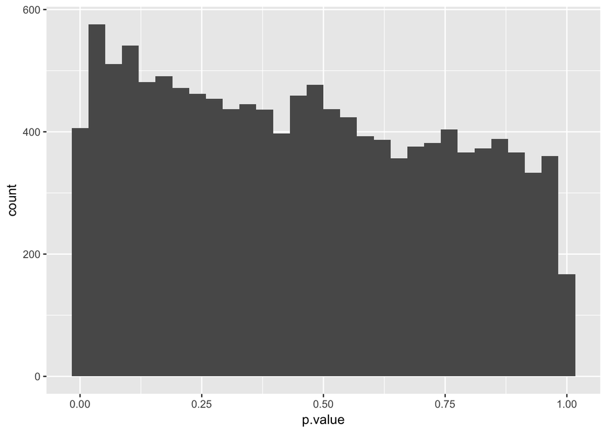

```r
ggplot(out, aes(p.value))+geom_histogram()
```

## Note

I created the dataset used here using the following code:

```r
source('http://bioconductor.org/biocLite.R')
biocLite('CLL')
library(CLL)
library(affy)
data(CLLBatch)
data(disease)
d <-  rma(CLLbatch)
dat <- t(as.data.frame(exprs(d)))
dat <- cbind(disease, dat)
write.csv(dat, file='geneexpressions.csv', row.names = F)
```